# Week 4 In-class Exercise

First, repeat the code to import the salmon counts

```r
library(readr)
library(tximport)
library(DESeq2)
library(dplyr)

dirs <- list.files("salmon_quant/")

quant_files <- list.files("salmon_quant/",pattern="quant.sf.gz",recursive = TRUE,full.names = TRUE)
names(quant_files) <- dirs

tx2gene <- read_csv("tx2gene.csv",col_names = FALSE)
txi <- tximport(quant_files,
                type="salmon",
                tx2gene = tx2gene,
                ignoreTxVersion = TRUE)
```

```
reading in files with read_tsv
1 2 3 4 5 6 7 8 9
summarizing abundance
summarizing counts
summarizing length
```

```r
sampleInfo <- read_csv("meta_data/sampleInfo.csv")
dds <- DESeqDataSetFromTximport(txi,
                                colData = sampleInfo,
                                design = ~Treated)
```

```
some variables in design formula are characters, converting to factorsusing counts and average transcript lengths from tximport
```

- Is the `plotPCA` plot based on all genes in the dataset? How can we change how many genes are used for the PCA analysis? Does this significantly change the plot? (HINT: check the documentation for the `plotPCA` function.)
- Do the samples appear to be separated based on the type of treatment applied?
- What problems can you see with the metadata?
- Can you label the identify of each sample? Look for help on `geom_text`if you haven’t used it before

```r
vsd <- vst(dds)
```

```
using 'avgTxLength' from assays(dds), correcting for library size
```

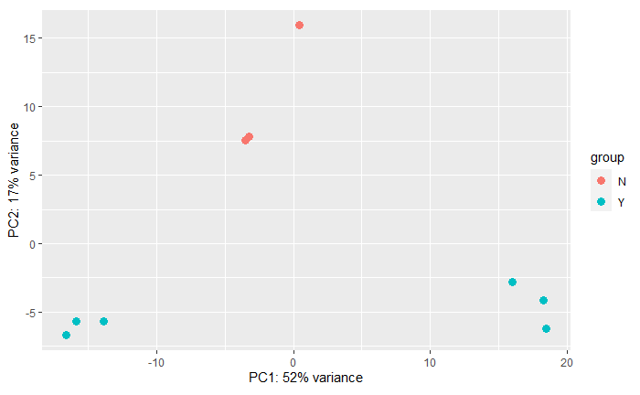

```r
plotPCA(vsd,intgroup="Treated")
```

Asking for the help on `plotPCA` suggests two possibilities. Pick the one that mentions `DESeq2`. The `plotPCA` function has a `ntop` argument which is set to `500`; in other words only 500 genes are used to make the plot. It does not seem to make a huge difference how many genes are used.

```r
?plotPCA
plotPCA(vsd, intgroup="Treated",ntop=1000)
plotPCA(vsd, intgroup="Treated",ntop=5000)
```

- Yes the samples appear to separate based on treatment
- There are more colours indicating condition than we would expect. There are typos in the values in this column that we need to fix

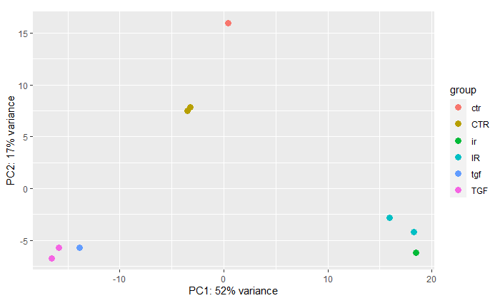

```r
plotPCA(vsd,intgroup="condition")
```

- Using the `geom_text` function requires a `label` aesthetic to be set. We can make this the `Name` column in `pca_data` for example.

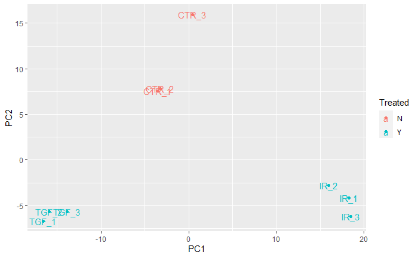

```r
library(ggplot2)
pca_data <- plotPCA(vsd,intgroup="Treated",returnData = TRUE) %>%
  dplyr::rename(Run = name) %>%
  left_join(sampleInfo)
  ggplot(pca_data,aes(x = PC1, y = PC2,col=Treated,label=Name)) + geom_point() + geom_text()
```

## Exercise

**Exercise:** - Re-create the `DESeqDataset` object to include the corrected sample information - Re-run the plotPCA function on the new data and verify that the sample groups now look correct

```r
library(stringr)
sampleInfo %>%
mutate(condition = as.factor(str_to_upper(condition))) %>%
write_tsv(file="meta_data/sampleInfo_corrected.txt")
```

We need to re-create the dds object using a modified version of `sampleInfo`. Only the `DESeqDataSetFromTximport` function needs to be changed.

```r
sampleInfo2 <- sampleInfo %>%
mutate(condition = as.factor(str_to_upper(condition)))

dds <- DESeqDataSetFromTximport(txi,
                                colData = sampleInfo2,
                                design = ~Treated)
```

```
some variables in design formula are characters, converting to factorsusing counts and average transcript lengths from tximport
```

```r
vsd <- vst(dds)
```

```
using 'avgTxLength' from assays(dds), correcting for library size
```

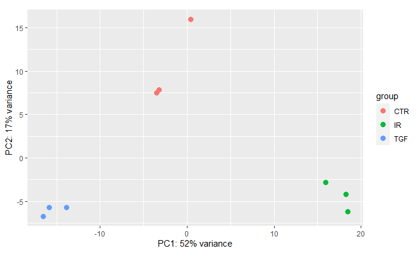

```r
plotPCA(vsd, intgroup = "condition")
```

## Exercise

**Exercise**: Use the appropriate `dplyr` functions to achieve the following:-

- Write the entire results table to a csv file
- Sort the differential expression results according to adjusted p-value
- Restrict the data to genes with adjusted p-value less than 0.05 and log2FoldChange > 1 or < -1

```r
de <- DESeq(dds)
```

```
using 'avgTxLength' from assays(dds), correcting for library size
```

```r
results(de, tidy=TRUE) %>%
  write_csv("DESeq_results.csv")
```

```r
results(de, tidy=TRUE) %>%
  arrange(padj)
```

| row | baseMean | log2FoldChange | lfcSE | stat | pvalue | padj |
| --- | --- | --- | --- | --- | --- | --- |
| ENSG00000158258 | 9.467885e+02 | 1.7296160 | 0.14057145 | 12.304177 | 8.600898e-35 | 1.882048e-30 |
| ENSG00000166396 | 2.149032e+03 | 1.3180391 | 0.13275101 | 9.928656 | 3.124383e-23 | 3.418388e-19 |
| ENSG00000136999 | 1.979854e+03 | -0.9550526 | 0.09738453 | -9.807026 | 1.050185e-22 | 7.660050e-19 |
| ENSG00000115594 | 6.675529e+03 | -1.8386389 | 0.19411313 | -9.471997 | 2.745451e-21 | 1.501899e-17 |
| ENSG00000019991 | 2.408455e+03 | -1.3475614 | 0.14640963 | -9.204049 | 3.447099e-20 | 1.508588e-16 |
| ENSG00000070193 | 3.560579e+01 | -3.1068705 | 0.34777171 | -8.933649 | 4.121829e-19 | 1.503231e-15 |
| ENSG00000168398 | 8.547403e+03 | -0.9129192 | 0.10286177 | -8.875204 | 6.980534e-19 | 2.182115e-15 |
| ENSG00000149256 | 7.648168e+02 | 3.4186553 | 0.38953367 | 8.776277 | 1.689755e-18 | 4.621903e-15 |
| ENSG00000119508 | 4.236249e+02 | -1.5553501 | 0.18015650 | -8.633328 | 5.959244e-18 | 1.448891e-14 |
| ENSG00000136960 | 6.373064e+03 | -1.0262768 | 0.11989090 | -8.560089 | 1.127803e-17 | 2.467857e-14 |

[output cut: 990 more lines]

```r
results(de, tidy = TRUE) %>%
  filter(padj < 0.05, log2FoldChange > 1 | log2FoldChange < -1)
```

| row | baseMean | log2FoldChange | lfcSE | stat | pvalue | padj |
| --- | --- | --- | --- | --- | --- | --- |
| ENSG00000003096 | 176.742996 | -1.522719 | 0.2702524 | -5.634435 | 1.756336e-08 | 6.742480e-06 |
| ENSG00000008056 | 33.646478 | 1.331003 | 0.3932734 | 3.384422 | 7.132824e-04 | 4.109150e-02 |
| ENSG00000019991 | 2408.454917 | -1.347561 | 0.1464096 | -9.204049 | 3.447099e-20 | 1.508588e-16 |
| ENSG00000046653 | 320.545954 | -1.908475 | 0.3644891 | -5.236029 | 1.640681e-07 | 5.279614e-05 |
| ENSG00000054938 | 13.091803 | -2.458693 | 0.6152753 | -3.996086 | 6.439848e-05 | 7.144924e-03 |
| ENSG00000055813 | 11.997222 | 3.106047 | 0.8511680 | 3.649159 | 2.631002e-04 | 2.012993e-02 |
| ENSG00000059377 | 131.393883 | -1.589972 | 0.4110383 | -3.868184 | 1.096489e-04 | 1.038674e-02 |
| ENSG00000060718 | 1521.832529 | 1.785344 | 0.2424700 | 7.363154 | 1.796147e-13 | 2.068594e-10 |
| ENSG00000065325 | 68.283448 | -1.368806 | 0.3802475 | -3.599776 | 3.184910e-04 | 2.315356e-02 |
| ENSG00000070193 | 35.605794 | -3.106870 | 0.3477717 | -8.933649 | 4.121829e-19 | 1.503231e-15 |

[output cut: 164 more lines]

[output not shown]

[output cut: 164 more lines]